# Prosper Loan Data Exploration

## Premilinary Wrangling

This document explores a dataset containing loan data from Prosper Ltd.

```python
#Importing necessary libraries
import pandas as pd
import numpy as np
import matplotlib.pyplot as plt
import seaborn as sns

%matplotlib inline
```

```python
#Loading the dataset into a pandas DataFrame
data = pd.read_csv("prosperLoanData.csv")
```

```python
#Obtain an overview of the data
print(data.shape)
```

```
(113937, 81)
```

```python
#Brief information of the data
print(data.info())
```

```
<class 'pandas.core.frame.DataFrame'>
RangeIndex: 113937 entries, 0 to 113936
Data columns (total 81 columns):
 #   Column                               Non-Null Count   Dtype
---  ------                               --------------   -----
 0   ListingKey                           113937 non-null  object
 1   ListingNumber                        113937 non-null  int64
 2   ListingCreationDate                  113937 non-null  object
 3   CreditGrade                          28953 non-null   object
 4   Term                                 113937 non-null  int64
 5   LoanStatus                           113937 non-null  object
 6   ClosedDate                           55089 non-null   object
 7   BorrowerAPR                          113912 non-null  float64
 8   BorrowerRate                         113937 non-null  float64
 9   LenderYield                          113937 non-null  float64
```

[output cut: 74 more lines]

```python
#Getting to know datatypes of the data
print(data.dtypes)
```

```
ListingKey                      object
ListingNumber                    int64
ListingCreationDate             object
CreditGrade                     object
Term                             int64
                                ...
PercentFunded                  float64
Recommendations                  int64
InvestmentFromFriendsCount       int64
InvestmentFromFriendsAmount    float64
Investors                        int64
Length: 81, dtype: object
```

```python
#First few rows of the data
data.head(6)
```

|  | ListingKey | ListingNumber | ListingCreationDate | CreditGrade | Term | LoanStatus | ClosedDate | BorrowerAPR | BorrowerRate | LenderYield | ... | LP_ServiceFees | LP_CollectionFees | LP_GrossPrincipalLoss | LP_NetPrincipalLoss | LP_NonPrincipalRecoverypayments | PercentFunded | Recommendations | InvestmentFromFriendsCount | InvestmentFromFriendsAmount | Investors |
| --- | --- | --- | --- | --- | --- | --- | --- | --- | --- | --- | --- | --- | --- | --- | --- | --- | --- | --- | --- | --- | --- |
| 0 | 1021339766868145413AB3B | 193129 | 2007-08-26 19:09:29.263000000 | C | 36 | Completed | 2009-08-14 00:00:00 | 0.16516 | 0.1580 | 0.1380 | ... | -133.18 | 0.0 | 0.0 | 0.0 | 0.0 | 1.0 | 0 | 0 | 0.0 | 258 |
| 1 | 10273602499503308B223C1 | 1209647 | 2014-02-27 08:28:07.900000000 | NaN | 36 | Current | NaN | 0.12016 | 0.0920 | 0.0820 | ... | 0.00 | 0.0 | 0.0 | 0.0 | 0.0 | 1.0 | 0 | 0 | 0.0 | 1 |
| 2 | 0EE9337825851032864889A | 81716 | 2007-01-05 15:00:47.090000000 | HR | 36 | Completed | 2009-12-17 00:00:00 | 0.28269 | 0.2750 | 0.2400 | ... | -24.20 | 0.0 | 0.0 | 0.0 | 0.0 | 1.0 | 0 | 0 | 0.0 | 41 |
| 3 | 0EF5356002482715299901A | 658116 | 2012-10-22 11:02:35.010000000 | NaN | 36 | Current | NaN | 0.12528 | 0.0974 | 0.0874 | ... | -108.01 | 0.0 | 0.0 | 0.0 | 0.0 | 1.0 | 0 | 0 | 0.0 | 158 |
| 4 | 0F023589499656230C5E3E2 | 909464 | 2013-09-14 18:38:39.097000000 | NaN | 36 | Current | NaN | 0.24614 | 0.2085 | 0.1985 | ... | -60.27 | 0.0 | 0.0 | 0.0 | 0.0 | 1.0 | 0 | 0 | 0.0 | 20 |
| 5 | 0F05359734824199381F61D | 1074836 | 2013-12-14 08:26:37.093000000 | NaN | 60 | Current | NaN | 0.15425 | 0.1314 | 0.1214 | ... | -25.33 | 0.0 | 0.0 | 0.0 | 0.0 | 1.0 | 0 | 0 | 0.0 | 1 |

6 rows × 81 columns

## Data Mungling

A deep dive into the data will be carried out at this process and any data issues found will be fixed.

I will put more emphasies on variables of interest so that a trustworthy analyses and visualizations can be achieved.

```python
#Picking variables of interest from the dataset
variables = ['ListingNumber','ListingCreationDate','ProsperRating (Alpha)','ProsperScore',\
            'ListingCategory (numeric)', 'Occupation','EmploymentStatus', \
            'IsBorrowerHomeowner', 'CurrentCreditLines', 'OpenRevolvingAccounts', 'DebtToIncomeRatio', \
            'IncomeVerifiable', 'LoanOriginalAmount', 'LoanStatus', \
            'CreditScoreRangeLower', 'CreditScoreRangeUpper','BorrowerState', \
            'LoanOriginationDate', 'IncomeRange','BorrowerAPR','BorrowerRate']
```

```python
#Create a new subset of the data
data_select = data[variables]
```

```python
#First few rows of the subset
data_select.head(5)
```

|  | ListingNumber | ListingCreationDate | ProsperRating (Alpha) | ProsperScore | ListingCategory (numeric) | Occupation | EmploymentStatus | IsBorrowerHomeowner | CurrentCreditLines | OpenRevolvingAccounts | ... | IncomeVerifiable | LoanOriginalAmount | LoanStatus | CreditScoreRangeLower | CreditScoreRangeUpper | BorrowerState | LoanOriginationDate | IncomeRange | BorrowerAPR | BorrowerRate |
| --- | --- | --- | --- | --- | --- | --- | --- | --- | --- | --- | --- | --- | --- | --- | --- | --- | --- | --- | --- | --- | --- |
| 0 | 193129 | 2007-08-26 19:09:29.263000000 | NaN | NaN | 0 | Other | Self-employed | True | 5.0 | 1 | ... | True | 9425 | Completed | 640.0 | 659.0 | CO | 2007-09-12 00:00:00 | $25,000-49,999 | 0.16516 | 0.1580 |
| 1 | 1209647 | 2014-02-27 08:28:07.900000000 | A | 7.0 | 2 | Professional | Employed | False | 14.0 | 13 | ... | True | 10000 | Current | 680.0 | 699.0 | CO | 2014-03-03 00:00:00 | $50,000-74,999 | 0.12016 | 0.0920 |
| 2 | 81716 | 2007-01-05 15:00:47.090000000 | NaN | NaN | 0 | Other | Not available | False | NaN | 0 | ... | True | 3001 | Completed | 480.0 | 499.0 | GA | 2007-01-17 00:00:00 | Not displayed | 0.28269 | 0.2750 |
| 3 | 658116 | 2012-10-22 11:02:35.010000000 | A | 9.0 | 16 | Skilled Labor | Employed | True | 5.0 | 7 | ... | True | 10000 | Current | 800.0 | 819.0 | GA | 2012-11-01 00:00:00 | $25,000-49,999 | 0.12528 | 0.0974 |
| 4 | 909464 | 2013-09-14 18:38:39.097000000 | D | 4.0 | 2 | Executive | Employed | True | 19.0 | 6 | ... | True | 15000 | Current | 680.0 | 699.0 | MN | 2013-09-20 00:00:00 | $100,000+ | 0.24614 | 0.2085 |

5 rows × 21 columns

```python
#A summary of the subset data with variables of interest
data_select.info()
```

```
<class 'pandas.core.frame.DataFrame'>
RangeIndex: 113937 entries, 0 to 113936
Data columns (total 21 columns):
 #   Column                     Non-Null Count   Dtype
---  ------                     --------------   -----
 0   ListingNumber              113937 non-null  int64
 1   ListingCreationDate        113937 non-null  object
 2   ProsperRating (Alpha)      84853 non-null   object
 3   ProsperScore               84853 non-null   float64
 4   ListingCategory (numeric)  113937 non-null  int64
 5   Occupation                 110349 non-null  object
 6   EmploymentStatus           111682 non-null  object
 7   IsBorrowerHomeowner        113937 non-null  bool
 8   CurrentCreditLines         106333 non-null  float64
 9   OpenRevolvingAccounts      113937 non-null  int64
 10  DebtToIncomeRatio          105383 non-null  float64
 11  IncomeVerifiable           113937 non-null  bool
 12  LoanOriginalAmount         113937 non-null  int64
 13  LoanStatus                 113937 non-null  object
 14  CreditScoreRangeLower      113346 non-null  float64
 15  CreditScoreRangeUpper      113346 non-null  float64
 16  BorrowerState              108422 non-null  object
 17  LoanOriginationDate        113937 non-null  object
 18  IncomeRange                113937 non-null  object
 19  BorrowerAPR                113912 non-null  float64
 20  BorrowerRate               113937 non-null  float64
dtypes: bool(2), float64(7), int64(4), object(8)
memory usage: 16.7+ MB
```

We notice that there are a few data issues like missing data which will be fixed on the next step.

```python
#Check for duplicates in the data
sum(data_select.duplicated())
```

```
0
```

```python
#Check for null values in the rows of the data
data_select.isnull().sum()
```

```
ListingNumber                    0
ListingCreationDate              0
ProsperRating (Alpha)        29084
ProsperScore                 29084
ListingCategory (numeric)        0
Occupation                    3588
EmploymentStatus              2255
IsBorrowerHomeowner              0
CurrentCreditLines            7604
OpenRevolvingAccounts            0
DebtToIncomeRatio             8554
IncomeVerifiable                 0
LoanOriginalAmount               0
LoanStatus                       0
CreditScoreRangeLower          591
CreditScoreRangeUpper          591
BorrowerState                 5515
LoanOriginationDate              0
IncomeRange                      0
BorrowerAPR                     25
BorrowerRate                     0
dtype: int64
```

### Handling Missing Values

```python
#Remove rows with missing Borrower APR information
data_select = data_select[~data_select.BorrowerAPR.isna()]
```

```python
#Selecting only rows with not null ProsperRating (Alpha) information
data_select = data_select[data_select['ProsperRating (Alpha)'].notnull()]
```

```python
#Selecting only rows with not null ProsperScore information
data_select = data_select[data_select['ProsperScore'].notnull()]
```

```python
#Filling missing values with unknown
data_select['Occupation'] = data_select['Occupation'].fillna('Unknown')
```

```python
#Filling missing values with unknown
data_select['EmploymentStatus'] = data_select['EmploymentStatus'].fillna('Unknown')
```

```python
#Filling missing values with mean
data_select['DebtToIncomeRatio'] = data_select['DebtToIncomeRatio'].fillna(data_select['DebtToIncomeRatio'].mean())
```

```python
#Confirming that we do not have any missing values
data_select.isnull().sum()
```

```
ListingNumber                0
ListingCreationDate          0
ProsperRating (Alpha)        0
ProsperScore                 0
ListingCategory (numeric)    0
Occupation                   0
EmploymentStatus             0
IsBorrowerHomeowner          0
CurrentCreditLines           0
OpenRevolvingAccounts        0
DebtToIncomeRatio            0
IncomeVerifiable             0
LoanOriginalAmount           0
LoanStatus                   0
CreditScoreRangeLower        0
CreditScoreRangeUpper        0
BorrowerState                0
LoanOriginationDate          0
IncomeRange                  0
BorrowerAPR                  0
BorrowerRate                 0
dtype: int64
```

```python
#New shape of our data
data_select.shape
```

```
(84853, 21)
```

```python
#Check for the number of unique values in the dataset
data_select.nunique()
```

```
ListingNumber                83982
ListingCreationDate          83980
ProsperRating (Alpha)            7
ProsperScore                    11
ListingCategory (numeric)       20
Occupation                      68
EmploymentStatus                 7
IsBorrowerHomeowner              2
CurrentCreditLines              51
OpenRevolvingAccounts           46
DebtToIncomeRatio              260
IncomeVerifiable                 2
LoanOriginalAmount            1934
LoanStatus                      11
CreditScoreRangeLower           15
CreditScoreRangeUpper           15
BorrowerState                   48
LoanOriginationDate           1165
IncomeRange                      7
BorrowerAPR                   2330
BorrowerRate                  1229
dtype: int64
```

```python
# Check unique Ocuppation
data_select.Occupation.unique()
```

```
array(['Professional', 'Skilled Labor', 'Executive', 'Sales - Retail',
       'Laborer', 'Food Service', 'Fireman', 'Construction',
       'Computer Programmer', 'Other', 'Sales - Commission',
       'Retail Management', 'Engineer - Mechanical', 'Military Enlisted',
       'Clerical', 'Unknown', 'Teacher', 'Clergy', 'Attorney',
       'Nurse (RN)', 'Accountant/CPA', 'Analyst', 'Investor',
       'Flight Attendant', 'Nurse (LPN)', 'Military Officer',
       'Truck Driver', 'Administrative Assistant',
       'Police Officer/Correction Officer', 'Social Worker',
       'Food Service Management', 'Tradesman - Mechanic',
       'Medical Technician', 'Professor', 'Postal Service',
       'Waiter/Waitress', 'Civil Service', 'Pharmacist',
       'Tradesman - Electrician', 'Scientist', 'Dentist',
       'Engineer - Electrical', 'Architect', 'Landscaping', 'Bus Driver',
       'Engineer - Chemical', 'Doctor', 'Chemist', "Teacher's Aide",
       'Pilot - Private/Commercial', "Nurse's Aide", 'Religious',
       'Homemaker', 'Realtor', 'Student - College Senior', 'Principal',
       'Psychologist', 'Biologist', 'Tradesman - Carpenter', 'Judge',
       'Car Dealer', 'Student - College Graduate Student',
       'Student - College Freshman', 'Student - College Junior',
       'Tradesman - Plumber', 'Student - College Sophomore',
       'Student - Community College', 'Student - Technical School'],
      dtype=object)
```

```python
#Check unique EmploymentStatus
data_select.EmploymentStatus.unique()
```

```
array(['Employed', 'Other', 'Full-time', 'Self-employed', 'Not employed',
       'Retired', 'Part-time'], dtype=object)
```

```python
#Check unique IsBorrowerHomeowner
data_select.IsBorrowerHomeowner.unique()
```

```
array([False,  True])
```

```python
#Check unique LoanStatus
data_select.LoanStatus.unique()
```

```
array(['Current', 'Past Due (1-15 days)', 'Defaulted', 'Completed',
       'Chargedoff', 'Past Due (16-30 days)', 'Past Due (61-90 days)',
       'Past Due (31-60 days)', 'Past Due (91-120 days)',
       'FinalPaymentInProgress', 'Past Due (>120 days)'], dtype=object)
```

```python
#Value counts for employment status
data_select.EmploymentStatus.value_counts()
```

```
Employed         67310
Full-time         7927
Self-employed     4538
Other             3806
Not employed       649
Retired            367
Part-time          256
Name: EmploymentStatus, dtype: int64
```

```python
#Confirming correction made have been taken into cosideration
data_select.info()
```

```
<class 'pandas.core.frame.DataFrame'>
Int64Index: 84853 entries, 1 to 113936
Data columns (total 21 columns):
 #   Column                     Non-Null Count  Dtype
---  ------                     --------------  -----
 0   ListingNumber              84853 non-null  int64
 1   ListingCreationDate        84853 non-null  object
 2   ProsperRating (Alpha)      84853 non-null  object
 3   ProsperScore               84853 non-null  float64
 4   ListingCategory (numeric)  84853 non-null  int64
 5   Occupation                 84853 non-null  object
 6   EmploymentStatus           84853 non-null  object
 7   IsBorrowerHomeowner        84853 non-null  bool
 8   CurrentCreditLines         84853 non-null  float64
 9   OpenRevolvingAccounts      84853 non-null  int64
 10  DebtToIncomeRatio          84853 non-null  float64
 11  IncomeVerifiable           84853 non-null  bool
 12  LoanOriginalAmount         84853 non-null  int64
 13  LoanStatus                 84853 non-null  object
 14  CreditScoreRangeLower      84853 non-null  float64
 15  CreditScoreRangeUpper      84853 non-null  float64
 16  BorrowerState              84853 non-null  object
 17  LoanOriginationDate        84853 non-null  object
 18  IncomeRange                84853 non-null  object
 19  BorrowerAPR                84853 non-null  float64
 20  BorrowerRate               84853 non-null  float64
dtypes: bool(2), float64(7), int64(4), object(8)
memory usage: 13.1+ MB
```

```python
#Obtaining descriptive statistics of numerical data
data_select.describe()
```

|  | ListingNumber | ProsperScore | ListingCategory (numeric) | CurrentCreditLines | OpenRevolvingAccounts | DebtToIncomeRatio | LoanOriginalAmount | CreditScoreRangeLower | CreditScoreRangeUpper | BorrowerAPR | BorrowerRate |
| --- | --- | --- | --- | --- | --- | --- | --- | --- | --- | --- | --- |
| count | 8.485300e+04 | 84853.000000 | 84853.000000 | 84853.000000 | 84853.000000 | 84853.000000 | 84853.000000 | 84853.000000 | 84853.000000 | 84853.000000 | 84853.000000 |
| mean | 7.738749e+05 | 5.950067 | 3.312647 | 10.508032 | 7.386292 | 0.258752 | 9083.440515 | 699.390240 | 718.390240 | 0.226658 | 0.196022 |
| std | 2.363387e+05 | 2.376501 | 4.364277 | 5.317401 | 4.515977 | 0.304333 | 6287.860058 | 47.095937 | 47.095937 | 0.079916 | 0.074631 |
| min | 4.162750e+05 | 1.000000 | 0.000000 | 0.000000 | 0.000000 | 0.000000 | 1000.000000 | 600.000000 | 619.000000 | 0.045830 | 0.040000 |
| 25% | 5.580860e+05 | 4.000000 | 1.000000 | 7.000000 | 4.000000 | 0.160000 | 4000.000000 | 660.000000 | 679.000000 | 0.163280 | 0.135900 |
| 50% | 7.392460e+05 | 6.000000 | 1.000000 | 10.000000 | 7.000000 | 0.240000 | 7500.000000 | 700.000000 | 719.000000 | 0.219450 | 0.187500 |
| 75% | 9.794360e+05 | 8.000000 | 3.000000 | 13.000000 | 10.000000 | 0.310000 | 13500.000000 | 720.000000 | 739.000000 | 0.292540 | 0.257400 |
| max | 1.255725e+06 | 11.000000 | 20.000000 | 59.000000 | 50.000000 | 10.010000 | 35000.000000 | 880.000000 | 899.000000 | 0.423950 | 0.360000 |

### What is the structure of your dataset?

Most variables are numeric and categorical in nature.

### What is/are the main feature(s) of interest in your dataset?

As a consultant to Prosper Limited Company, I am interested in figuring out which factors the firm should put more emphasison when lending money to their clients and the general prospects that will enhace profitability of the firm such as lending funds to borrowers who have a low risk of default.

### What features in the dataset do you think will help support your investigation into your feature(s) of interest?

For the analysis to be successful, several features have to be explored in-depth so as to come up with a trustworthy report.

More emphasis will be layed in the following features which prove to be of more use in this analysis:

> I will focus on features that the firm should put consideration in when determining if a client is worth being given a loan. The fearures of interest are: Occupation, Employment status, Collateral(is the borrower a home owner), Debt-to-income ratio, Original loan amount, Loan status and Income range.

## Univariate Exploration

I will investigate features that I am mostly interested in using for my analysis.

### Debt To Income Ratio

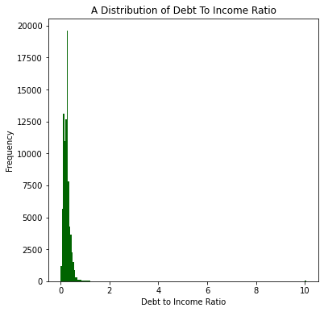

```python
# Plot DebtToIncomeRatio
binsize = 0.05
bins = np.arange(0, data_select['DebtToIncomeRatio'].max()+binsize, binsize)
plt.figure(figsize=[6,6])
plt.hist(data = data_select, x = 'DebtToIncomeRatio', bins = bins, color='darkgreen')
plt.xlabel('Debt to Income Ratio')
plt.ylabel('Frequency')
plt.title('A Distribution of Debt To Income Ratio');
```

### Notes

A Debt To Income Ratio compares how much an individual owes in each month in comparison to income they get. A high debt to income ratio signifies that an individual uses a large portion of their income to pay debt. On the other hand, a low debt to income ratio demonstrates that the individual is using a relatively small amount of their income to pay debt.

From the above histogram, it is seen that a vast majority of the borrowers have a Debt To Income ratio of around 30%.

### BorrowerRate

```python
#Defining a function
def myHist(data, xVar):
    '''
    doctring: creating a function that creates a histogram of the data
    inputs: the arguments required for the inputs of the histogram are the data and the x variable
    outputs: the function creates a histogram of the data
    '''

    #Set plot dimension
    plt.figure(figsize=[12,8])

    #Plot
    plt.hist(data=data_select, x='BorrowerRate', bins=30, color='darkgreen')
    plt.title('A Histogram of BorrowerRate')
    plt.xlabel('BorrrowerRate')
    plt.ylabel('Frequency')
```

Plotting the histogram:

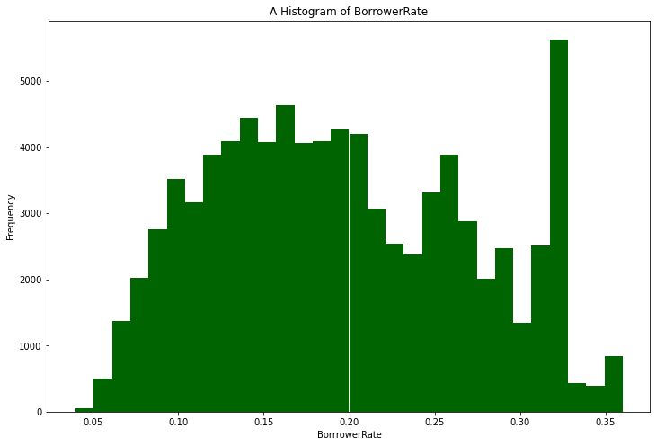

```python
myHist(data_select, data_select['BorrowerRate'])
```

### Employment Status

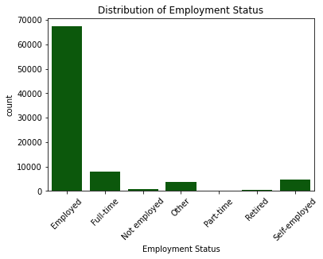

```python
#Plot employment status
emp_status = data_select.EmploymentStatus.value_counts().index
sns.countplot(data=data_select, x='EmploymentStatus', order=sorted(emp_status), color='darkgreen')
plt.xlabel('Employment Status')
plt.title('Distribution of Employment Status')
plt.xticks(rotation=45);
```

### Notes

A vast majority of the borrowers are employed. This is logicall as it would be difficult for an unemployed individual to be given a loan which translates to difficulty in servicing the loan.

### Occupation

```python
#Obtain value counts of occupation
occupation = data_select['Occupation'].value_counts()
occupation
```

```
Other                          21317
Professional                   10542
Executive                       3468
Computer Programmer             3236
Teacher                         2888
                               ...
Judge                             22
Student - College Freshman        17
Student - College Sophomore       16
Student - Community College       10
Student - Technical School         2
Name: Occupation, Length: 68, dtype: int64
```

```python
#Selecting top 10 occupations
top = data_select.Occupation.value_counts()[:10]
top
```

```
Other                       21317
Professional                10542
Executive                    3468
Computer Programmer          3236
Teacher                      2888
Analyst                      2735
Administrative Assistant     2708
Accountant/CPA               2574
Sales - Commission           2350
Skilled Labor                2180
Name: Occupation, dtype: int64
```

### Loan Original Amount

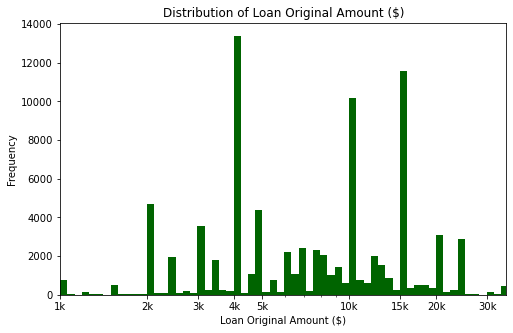

```python
#Plot the loan original amount against a log scale
log_binsize = 0.025
bins_log = 10 ** np.arange(3, np.log10(data_select['LoanOriginalAmount'].max())+log_binsize, log_binsize)
plt.figure(figsize=[8,5])
plt.hist(data = data_select, x = 'LoanOriginalAmount', bins = bins_log, color='darkgreen')
plt.xscale('log')
x_ticks = [1000, 2000, 3000, 4000, 5000, 10000, 15000,20000, 30000]
x_ticks_names = ['1k','2k', '3k', '4k', '5k', '10k','15k', '20k','30k']
plt.xticks(x_ticks, x_ticks_names)
plt.xlim((1000,35000))
plt.xlabel('Loan Original Amount ($)')
plt.ylabel('Frequency')
plt.title('Distribution of Loan Original Amount ($)');
```

### Loan Status

[figure not shown]

```python
#Plot the loan status
loan_status = data_select.LoanStatus.value_counts().index

#Plot
sns.countplot(data=data_select, y='LoanStatus', order=sorted(loan_status), palette='viridis')
plt.figure(figsize=[10,2]);
```

### Notes

The most common loan status is current. Since we have many categories which reduce clarity, I will aggregate some of the categories into one.

Ploting LoanStatus vs Frequency

Data preparation.

```python
# Aggregate Past Due loans
data_select['LoanStatus'] = data_select['LoanStatus'].apply(lambda x: x if 'Past Due' not in x else 'Past Due')

# Convert LoanStatus to a categorical variable
grp_loan = ['Defaulted','Chargedoff', 'Past Due', 'Current', 'FinalPaymentInProgress', 'Completed']

loan_status_order = pd.api.types.CategoricalDtype(ordered = True, categories = grp_loan)

data_select['LoanStatus'] = data_select['LoanStatus'].astype(loan_status_order)
```

Now that I have aggregated the categories, next I will pront the proportion of each loan status.

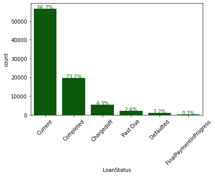

```python
#Print proportion on the bars
n_loans=data_select['LoanStatus'].value_counts().sum()
status_count=data_select['LoanStatus'].value_counts()
status_order=status_count.index

sns.countplot(data=data_select, x='LoanStatus', color="darkgreen", order=status_order);

# get the current tick locations and labels
locs, labels = plt.xticks(rotation=45)

# loop through each pair of locations and labels
for loc, label in zip(locs, labels):
    # get the text property for the label to get the correct count
    count = status_count[label.get_text()]
    pct_string = '{:0.1f}%'.format(100*count/n_loans)

    # print the annotation just below the top of the bar
    plt.text(loc, count+2, pct_string, ha = 'center', color='darkgreen')
```

### Notes

More than 80% of all Prosper loans are either current or completed (good profiles). Among them, almost 67% are current and being paid by Prosper's borrowers. However, about 8% of Prosper's loans were charged-off or defaulted. Moreover, the remaining 2.4% of loans has the status Past Due and was grouped under a single status: Past Due.

### Discuss the distribution(s) of your variable(s) of interest. Were there any unusual points? Did you need to perform any transformations?

The loan original amount variable took on a large range of values, so I looked at the data using a log transform. Under the transformation, the data have three peaks at 4K, 10K, and 15K.

### Of the features you investigated, were there any unusual distributions? Did you perform any operations on the data to tidy, adjust, or change the form of the data? If so, why did you do this?

There were no unsual distributions in the data, at least that I was able to notice. However, my cleaning efforts were geared towards making the data to make more sense.

## Bivariate Exploration

At this point, I will focus on looking at relationships between pairs of features of the data.

##### Determinig correlation between numeriacl variables

```python
#Numerical variables
numeric_vars = [ 'CurrentCreditLines','DebtToIncomeRatio', 'BorrowerRate',
                'LoanOriginalAmount', 'BorrowerAPR', 'OpenRevolvingAccounts']
```

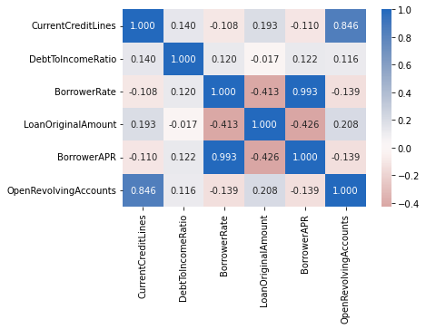

```python
#Correlation plot
sns.heatmap(data_select[numeric_vars].corr(), annot = True, fmt = '.3f',
           cmap = 'vlag_r', center=0)
plt.show()
```

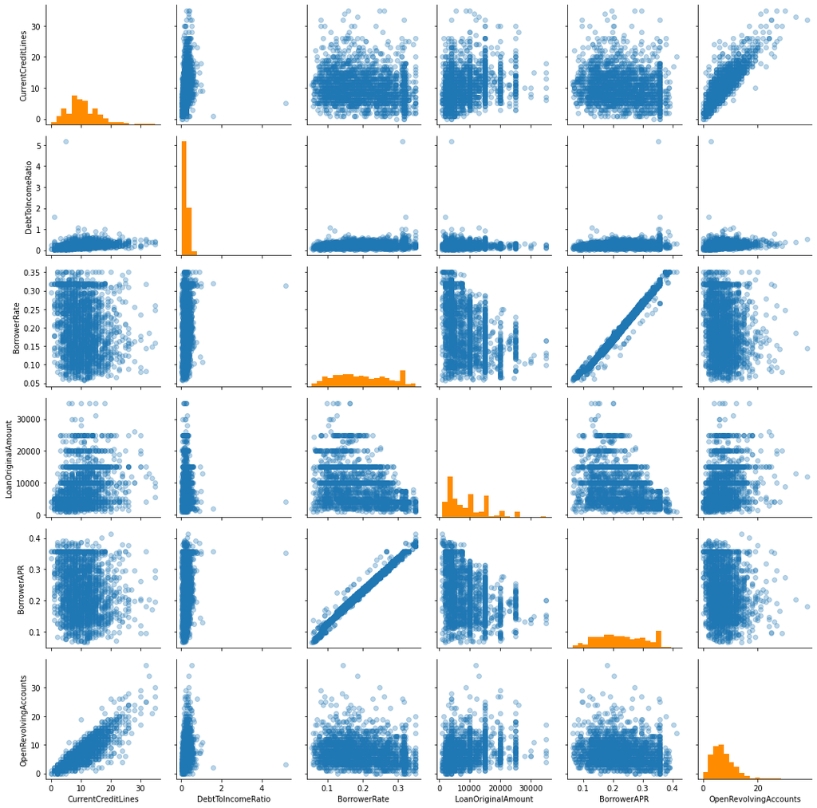

```python
# plot matrix: sample 2000 loans so that plots are clearer
loan_sample = data_select.sample(2000)
g = sns.PairGrid(data = loan_sample, vars = numeric_vars)
g = g.map_diag(plt.hist, bins=20, color='darkorange')
g.map_offdiag(plt.scatter, alpha=0.3);
```

### Notes

There is a very high correlation between OpenRevolvingAccounts and CurrentCreditLines. We can also observe a high correlation between BorrowerRate and Borrower APR with a correlation coefficient of 0.993.

### Relationship between BorrowerAPR and Employment status

Creating a box plot.

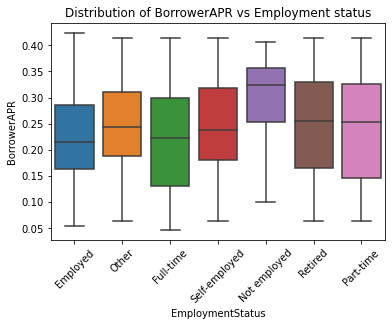

```python
#Box plot
sns.boxplot(data=data_select, x=data_select['EmploymentStatus'], y=data_select['BorrowerAPR'])
plt.xticks(rotation=45)
plt.title('Distribution of BorrowerAPR vs Employment status');
```

### Notes

The BorrowerAPR for unemployed indivituals is slightly higher than the rest since they have a higher risk of default.

### Relation between BorrowerRate and Employment status

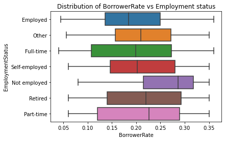

```python
#Box plot
sns.boxplot(data=data_select, y=data_select['EmploymentStatus'], x=data_select['BorrowerRate'])

plt.title('Distribution of BorrowerRate vs Employment status');
```

### Relationship between BorrowerAPR and ProsperRating

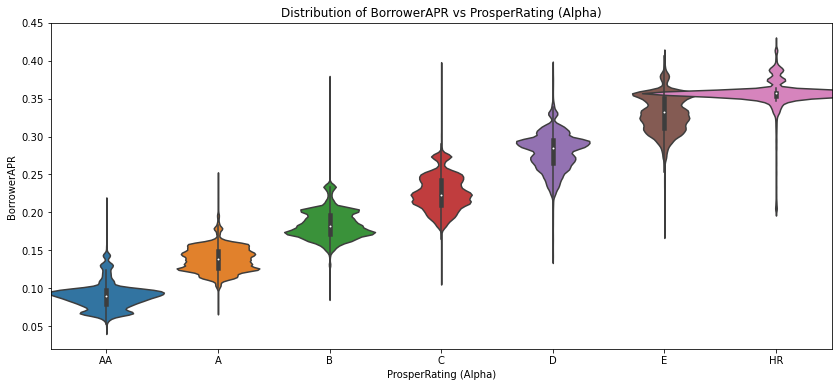

```python
credit_rating = ['AA', 'A', 'B', 'C', 'D', 'E', 'HR']

#Set plot dimensions
plt.figure(figsize=[14,6])
#Violin plot
sns.violinplot(data=data_select, y=data_select['BorrowerAPR'], x=data_select['ProsperRating (Alpha)'],
                             order = credit_rating, width=2.4)
plt.title('Distribution of BorrowerAPR vs ProsperRating (Alpha)');
```

### Notes

Borrowers with AA Prosper rating tend to be charged a lower rate on their loans while those with HR Prosper rating are charged the highest rates on their loans due to their high risk of default.

### Relationship between a Loan Amount and EmploymentStatus

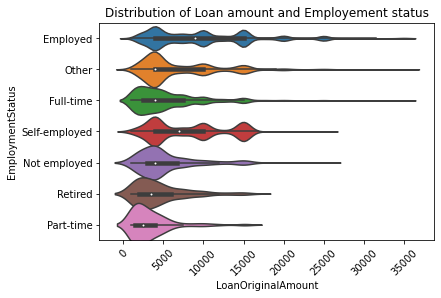

```python
#Violin plot
sns.violinplot(data=data_select, x=data_select['LoanOriginalAmount'], y=data_select['EmploymentStatus'],
                             width=1.4)
plt.xticks(rotation=45)
plt.title('Distribution of Loan amount and Employement status');
```

### Notes

As expected, individuals who are employed are awarded a large loan amount. This is simply because they have a regular sours of income and are therefore able to service their loans with ease as signed in the loan contract.

### Relationship between a Loan Amount and BorrowerAPR on a regression plot.

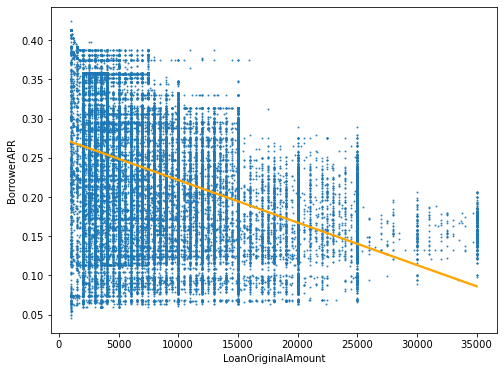

```python
#Regplot
plt.figure(figsize = [8, 6])
sns.regplot(data = data_select, x = 'LoanOriginalAmount', y = 'BorrowerAPR',
            scatter_kws={'s':1}, line_kws={'color':'orange'});
```

### Notes

As the loan amount increases, the BorrowerAPR descreases. There is therefore a negative correlatio between the two variables.

### Talk about some of the relationships you observed in this part of the investigation. How did the feature(s) of interest vary with other features in the dataset?

My aim is to establish the factors that affect rates charged on loans and how different loan amounts are distributed among different categories of people.

```
 -The findings of the analysis carried out is that individuals who get a loan from Prosper and are not employed are charged more rates on their loan. This true because they do not have a regular stream of income and are therefore at a higher risk of defaulting.

 -It is also observed that as the loan amount increases, the BorrowerAPR descreases. There is therefore a negative correlatio between the two variables.

 -Another observation made was that borrowers with AA Prosper rating tend to be charged a lower rate on their loans while those with HR Prosper rating are charged the highest rates on their loans due to their high risk of default.
```

### Did you observe any interesting relationships between the other features (not the main feature(s) of interest)?

The observation I made was taht borrowers with AA Prosper rating tend to be charged a lower rate on their loans while those with HR Prosper rating are charged the highest rates on their loans due to their high risk of default.

## Multivariate Exploration

```
More empasis will be layed on determining multiple variables that affect rates charged on loans and how different loan amounts are distributed among different categories of people by creating plots with three or more variables.
```

### Establishing the relationship between Loan Amount and Borrower Rate.

```python
#Create a new column which return 1 for good status of payment('Current','Completed','FinalPaymentInProgress')
# and 0 if there is an issue (defaulted,past due, charged-off payments)

recommend_loan=['Current','Completed','FinalPaymentInProgress']
def loanstatus_val(doc):
    for i in recommend_loan:
        if i in doc:
            return 1
    return 0
data_select["loan_status"] = data_select.LoanStatus.apply(lambda x: loanstatus_val(x))
```

```python
response = data_select.groupby('loan_status').agg({'LoanOriginalAmount':'mean','BorrowerRate':'mean'})
response = response.reset_index()
response["loan_status"].replace({0: "Not Recommended", 1: "Recommeded"}, inplace=True)
response = response.sort_values(['LoanOriginalAmount'],ascending=False).head(10)
response
```

|  | loan_status | LoanOriginalAmount | BorrowerRate |
| --- | --- | --- | --- |
| 1 | Recommeded | 9344.255478 | 0.189706 |
| 0 | Not Recommended | 6712.127498 | 0.253447 |

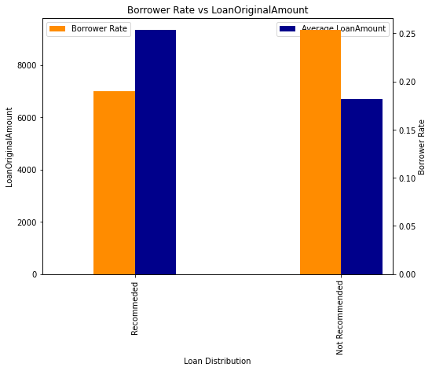

```python
# Create a figure
fig = plt.figure(figsize=(8,6))
# Create matplotlib axes
ax = fig.add_subplot(111)
# Create another axes
ax2 = ax.twinx()

width = 0.20
LoanOriginalAmount = response.plot(x='loan_status', y='LoanOriginalAmount', kind='bar', color = 'darkblue',
                   width=width,ax=ax, position = 0, label = 'Average LoanAmount')
BorrowerRate = response.plot(x='loan_status', y='BorrowerRate', kind='bar', color = 'darkorange',
                  width=width,ax=ax2, position = 1,  label = 'Borrower Rate')

ax.set_ylabel('LoanOriginalAmount')
LoanOriginalAmount.legend(loc='upper right')
ax2.set_ylabel('Borrower Rate')
ax2.legend(loc='upper left')
ax.set_xlabel('Loan Distribution')
plt.xticks(rotation=45)
plt.title('Borrower Rate vs LoanOriginalAmount');
```

We can clearly observe that the borrower rate charged on loans offered by Prosper is dependent on the loan amount.A larger loan amount attracts a smaller rate and there is an inverse relationship.

#### Plotting EmployementStatus against BorrowerRate and Is BorrowerHomeOwner

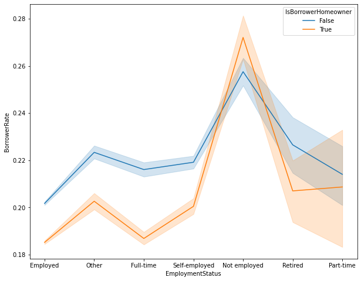

```python
# plots the lineplot to analyze homeowner's and non-homeowner's rate over years
plt.figure(figsize=(10,8))
g=sns.lineplot(data=data_select, x='EmploymentStatus', y='BorrowerRate', hue='IsBorrowerHomeowner')
```

### Notes

Rates charged by Prosper are based on whether the borrower owns a home or not and their employement status. Owning a home serves as a collateral to the loan taken. Individuals without homes are charged a higher rate because they do not have homes to be used as collateral.

Employment is also a factor considered when charging rates on loans. Because unemployed individuals lack regular income to service their loan, they are charged higher rates as compared to their peers as they have a higher risk of defaulting.

Employed people attract lower rates charged on their loans.

.

I proceed to establish the relationship between Borrower APR by Employment and loan status.

### Borrower APR (Annual cost) by Employment status and loan Status

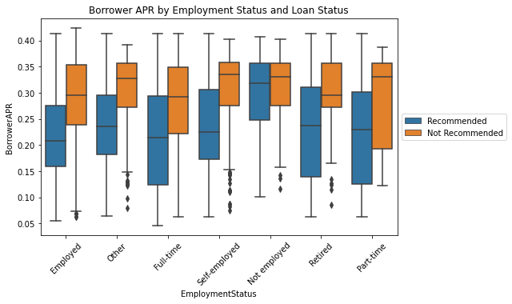

```python
data_select["loan_status"].replace({0: "Not Recommended", 1: "Recommended"}, inplace=True)
plt.figure(figsize=[8, 5])
sns.boxplot(data=data_select,x='EmploymentStatus',y='BorrowerAPR',hue='loan_status',dodge=0.3)
plt.title('Borrower APR by Employment Status and Loan Status')
plt.xticks(rotation=45);
plt.legend(loc = 6, bbox_to_anchor = (1.0, 0.5));
```

As was observed earlier, the figure confirms our earlier findings that borrower rate is higher for unemployed individuals and loans with bad records.

### Talk about some of the relationships you observed in this part of the investigation. Were there features that strengthened each other in terms of looking at your feature(s) of interest?

My aim is to establish the factors that affect rates charged on loans and how different loan amounts are distributed among different categories of people.

After carrying out the analysis and investigating how the different variables correlate with each other, I established the following trends:

```
 The findings of the analysis carried out is that individuals who get a loan from Prosper and are not employed are charged more rates on their loan. This true because they do not have a regular stream of income and are therefore at a higher risk of defaulting.

 It is also observed that as the loan amount increases, the BorrowerAPR descreases. There is therefore a negative correlatio between the two variables.

 It is evident that indviduals that are at a high risk of defaulting such as those who are unemployed, those who do not own homes which serve as a collateral for taking the loan are considerd as risky and are theredore charged higher rates on the loans awarded to them.
```